# Grammar of Group Sequential Design

September 1, 2022, Bremen

## Philosophy

“It is more fun to talk with someone who doesn’t use long, difficult words but rather short, easy words like ‘What about lunch?’” — A. A. Milne, *Winnie-the-Pooh*

## Co-authors

- Yilong Zhang, Meta Platforms, Inc.
- Nan Xiao, Merck & Co., Inc.
- Yujie Zhao, Merck & Co., Inc.

## Disclaimer

These materials do not represent corporate thoughts of Merck & Co., Inc., Rahway, NJ, USA and its affiliates, or Meta Platforms, Inc.

Keaven Anderson takes responsibility for any errors.

## Overview

- Grammar of group sequential design is an ongoing initiative
  - Enabling new and potentially extensive capabilities
  - Simplified command structure
- Current status
  - Many capabilities implemented
  - Progress on grammar
- Today’s presentation
  - Fixed design example
  - Introduction to grammar priorities
- Group sequential bound grammar coming later

Aim is to support specific design innovations coming into common use

## New capabilities represent opinionated priorities

## Opinionated selection of new features

- Non-proportional hazards asymptotics for group sequential design
  - Weighted logrank and combination test design: Roychoudhury et al. (2021); Magirr and Jiménez (2022)
- Many more bound options
  - Spending other than information-based
  - One or both of efficacy and futility bound at each analysis
- Time-to-event endpoint with parallel simulation
- Graphical multiplicity and parametric design (Anderson et al. 2022)
  - Account for group sequential and multiple hypothesis correlations
  - Multiple experimental arms (e.g., MAMS)
  - Intersecting populations
- Designs for stratified populations
  - Binomial or time-to-event outcomes with differing treatment effects (Mehrotra and Railkar 2000)

## Some Merck Shiny innovations

- [**gsDesign**](https://rinpharma.shinyapps.io/gsdesign/)
  - Design and design update with **gsDesign** package
  - Save and reproduce designs
  - Design code and documentation generation (RMarkdown)
  - Video introduction at https://www.youtube.com/watch?v=8uZRuvzma9M
- **gMCPLite**
  - Recent work by Yalin Zhu, Xuan Deng
  - Graphical multiplicity with **ggplot2** graphics https://merck.github.io/gMCPLite/
    - Removes RJava to make lightweight package
  - Package at https://cran.r-project.org/web/packages/gMCPLite/index.html
    - Post issues at https://github.com/Merck/gMCPLite
  - Ongoing work includes Shiny interface

## Some Merck packages and repositories

- **gsDesign** ongoing updates for PH
- **gsDesign2** for non-proportional hazards
  - Asymptotic design (**gsdmvn** now being merged into **gsDesign2**)
  - Simulation (**simtrial**)
- Graphical multiplicity with group sequential design (Anderson et al. 2022)
  - https://github.com/zifangguo/WPGSD_Supp_Programs

There are also many non-Merck packages

## Packages used here

```r
# New grammar and capabilities
library(gsdmvn)    # To be combined with gsDesign2
library(gsDesign2)

# Standalone time-to-event simulation
library(simtrial)

# Supported since 2007
library(gsDesign)

# tidyverse packages
library(tibble)
library(gt)
library(dplyr)
```

## Piecewise model

## Setup input parameters

Enrollment rates (piecewise constant, fixed total duration for NPH approach)

| Stratum | duration | rate |
| --- | --- | --- |
| All | 18 | 20 |

Failure and dropout rates (piecewise constant, piecewise hazard ratio)

| Stratum | duration | failRate | hr | dropoutRate |
| --- | --- | --- | --- | --- |
| All | 4 | 0.05776227 | 1.0 | 0.001 |
| All | 100 | 0.05776227 | 0.6 | 0.001 |

- Simple to express to collaborators
  - Median control survival: 12 months
  - 4 month delay in benefit, HR = 0.6 thereafter
- Able to approximate arbitrary enrollment, failure and dropout rates

## Other input parameters

```r
# Study duration in months
studyDuration <- 36
# Experimental / Control randomization ratio
ratio <- 1
# 1-sided Type I error
alpha <- 0.025
# Type II error (power may be a bad argument choice)
beta <- .1
```

## Desire is to make grammar flexible, simple, consistent

- Rigorous interface (API) for constructing and validating inputs with sensible defaults
- Composable operations for creating pipe-friendly workflows
- Unified underlying data representation for extensibility
- Work is underway; starting efforts with R7 (Wickham, 2022)

## R7 thoughts

- Test version for time-to-event group sequential design written in R7
  - Old version in S3
  - We have also tested Q7 as another OOP system
  - R7 is in *alpha* mode (very early)
  - Our initial experience (~500 lines of code) is very promising
- OOP: object oriented programming
  - Rigorous input checking at time of design construction
  - Checking gives more useful error detection and feedback
  - Enable extensibility
- Grammar
  - Opportunity to reconsider grammar standards from 2009 (Revolution Computing)
  - Concise and clear naming conventions
  - Expanding capabilities

## Average hazard ratio

## Average hazard ratio

Easy to describe expected effect over time

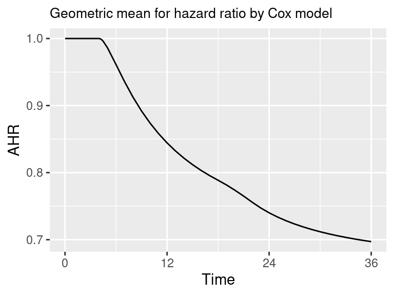

```r
AHR(
  enrollRates = enrollRates,
  failRates = failRates,
  totalDuration = c(.01, seq(4, 4.5, .1), 5:36),
  ratio = 1
) %>%
  ggplot(aes(x = Time, y = AHR)) +
  geom_line() +
  ggtitle("Geometric mean for hazard ratio by Cox model") +
  scale_x_continuous(breaks = seq(0, 36, 12))
```

## Using asymptotic calculations to examine design robustness

## What questions can we answer without simulation?

- What is the impact of different HR?
- What is the impact of delayed effect or crossing survival?
- What is the impact of strata prevalence?
- What is the impact of enrollment?
- What is the effect of follow-up duration?
- What is the impact of interim analysis (IA) timing?
- What is the impact of adding interim analysis?
- What is the impact of different futility bounds?
- What is the impact of different statistical tests?
- What is the impact of alpha allocation?
- What is the impact of incorporating parametric tests accounting for correlations?

## Get sample size for logrank using average hazard ratio

Method: AHR = average hazard ratio for NPH (Mukhopadhyay et al. 2020)

```r
x <- fixed_design(
  x = "AHR", alpha = alpha, power = 1 - beta, ratio = 1,
  enrollRates = enrollRates, failRates = failRates,
  studyDuration = studyDuration
)
x %>% summary() %>% as_gt()
```

Fixed Design under AHR Method<sup>1</sup>

| Design | N | Events | Time | Bound | alpha | Power |
| --- | --- | --- | --- | --- | --- | --- |
| AHR | 463.078 | 324.7077 | 36 | 1.959964 | 0.025 | 0.9 |

<sup>1</sup> Power computed with average hazard ratio method.

Other methods available: Lachin and Foulkes (Lachin and Foulkes 1986), Fleming-Harrington (Harrington and Fleming 1982), MaxCombo (Karrison et al. 2016; Roychoudhury et al. 2021), Modestly Weighted Logrank (Magirr and Burman 2019), Milestone difference, RMST. Many of these implemented by **npsurvSS** package (Yung and Liu 2019).

## Verify asymptotic power approximation by simulation

Compare power of tests under 4 month effect delay scenario

| Design | N | Events | Time | Bound | alpha | Power | Simulated power<sup>1</sup> | Simulated alpha |
| --- | --- | --- | --- | --- | --- | --- | --- | --- |
| Average hazard ratio | 463.1 | 324.7 | 36 | 1.959964 | 0.0250 | 0.9000 | 0.8960 | 0.0253 |
| Lachin and Foulkes | 463.1 | 328.9 | 36 | 1.959964 | 0.0250 | 0.9060 | NA | NA |
| Fleming-Harrington FH(0, 0) (logrank) | 463.1 | 324.7 | 36 | 1.959964 | 0.0250 | 0.9029 | 0.8971 | 0.0226 |
| Fleming-Harrington FH(0, 0.5) | 463.1 | 324.7 | 36 | 1.959964 | 0.0250 | 0.9584 | 0.9533 | 0.0260 |
| MaxCombo: logrank, FH(0, 0.5) | 463.1 | 324.7 | 36 | 1.959964 | 0.0250 | 0.9565 | 0.9415 | 0.0255 |
| MaxCombo: logrank, FH(0, 0.5), FH(0.5, 0.5) | 463.1 | 324.7 | 36 | 1.959964 | 0.0250 | 0.9585 | 0.9455 | 0.0276 |
| Modestly weighted LR: tau = 4 | 463.1 | 324.7 | 36 | 1.959964 | 0.0250 | 0.9198 | 0.9180 | 0.0233 |
| Modestly weighted LR: tau = 12 | 463.1 | 324.7 | 36 | 1.959964 | 0.0250 | 0.9449 | 0.9383 | 0.0215 |
| Modestly weighted LR: tau = 18 | 463.1 | 324.7 | 36 | 1.959964 | 0.0250 | 0.9486 | 0.9404 | 0.0234 |
| RMST: tau = 36 | 463.1 | 324.7 | 36 | 1.959964 | 0.0250 | 0.8760 | 0.8883 | 0.0277 |

<sup>1</sup> Simulated power and alpha is based on 10,000 simulations.

## Comparing different tests for robust power

## Scenarios considered

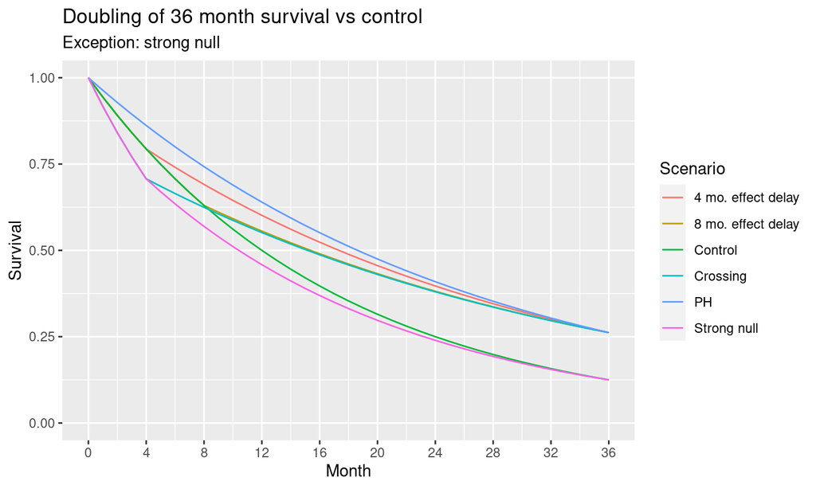

Strong null addresses Magirr and Burman (2019), Freidlin and Korn (2019)

## Check for robust power by test and scenario

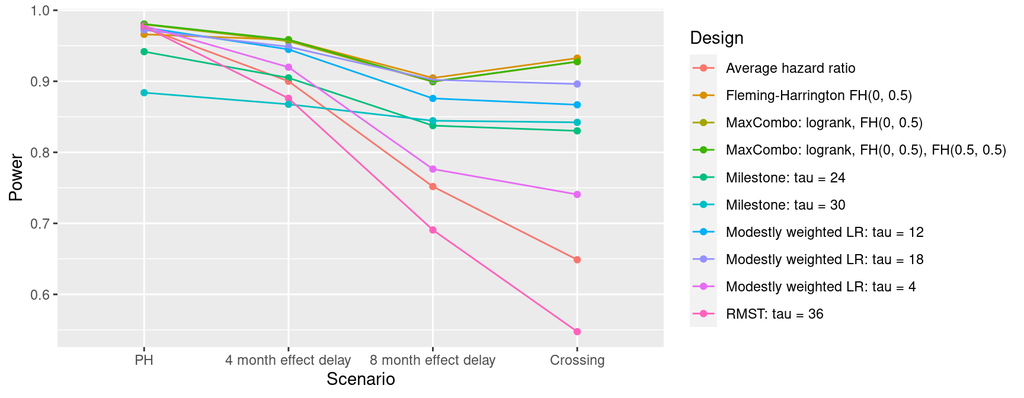

- Scenarios focused on long-term benefit, not short-term trade offs
- Logrank (average hazard ratio) and RMST lose considerable power with delayed benefit
- Many weighted logrank and combination tests retain good power across scenarios
  - Modestly weighted logrank may need to down-weight for much longer than effect delay

## Strong null: Need to control \(\alpha=0.025\) across entire null space

| Test | alpha |
| --- | --- |
| Strong null |  |
| Logrank | 0.0029 |
| Fleming-Harrington FH(0, 0.5) | 0.0163 |
| MaxCombo: logrank, FH(0, 0.5) | 0.0163 |
| MaxCombo: logrank, FH(0, 0.5), FH(0.5, 0.5) | 0.0166 |
| MaxCombo: logrank, FH(0, 1) | 0.0344 |
| MaxCombo: logrank, FH(0, 1), FH(1, 1) | 0.0366 |
| Modestly weighted LR: tau = 4 | 0.0043 |
| Modestly weighted LR: tau = 12 | 0.0098 |
| Modestly weighted LR: tau = 18 | 0.0132 |
| RMST: tau = 36 | 0.0022 |
| Milestone: tau = 24 | 0.0135 |
| Milestone: tau = 30 | 0.0203 |

- Excess Type I error with too much early down-weighting (FH(0,1))
  - In spite of 18 month enrollment
- Type I error well-controlled by less down-weighting
  - e.g., Modestly Weighted logrank (Magirr and Burman (2019)) or FH(0,0.5)-based (Roychoudhury et al. (2021)) tests

## Summary

- Description of useful new design features
- Initial grammar demonstrating
  - Ease of use
  - Broad applications to implement and compare designs
- Work is ongoing for both grammar and more features
- See Mukhopadhyay et al. (2022) for a systematic review of logrank vs RMST vs MaxCombo for 8+ years of immunotherapy trials in oncology

## Thank you

*Email:* Keaven_Anderson@merck.com

## References

Anderson, Keaven M, Zifang Guo, Jing Zhao, and Linda Z Sun. 2022. “A Unified Framework for Weighted Parametric Group Sequential Design.” *Biometrical Journal*.

Freidlin, Boris, and Edward L Korn. 2019. “Methods for Accommodating Nonproportional Hazards in Clinical Trials: Ready for the Primary Analysis?” *Journal of Clinical Oncology* 37 (35): 3455.

Harrington, David P, and Thomas R Fleming. 1982. “A Class of Rank Test Procedures for Censored Survival Data.” *Biometrika* 69 (3): 553–66.

Karrison, Theodore G et al. 2016. “Versatile Tests for Comparing Survival Curves Based on Weighted Log-Rank Statistics.” *Stata Journal* 16 (3): 678–90.

Lachin, John M., and Mary A. Foulkes. 1986. “Evaluation of Sample Size and Power for Analyses of Survival with Allowance for Nonuniform Patient Entry, Losses to Follow-up, Noncompliance, and Stratification.” *Biometrics* 42: 507–19.

Magirr, Dominic, and Carl-Fredrik Burman. 2019. “Modestly Weighted Logrank Tests.” *Statistics in Medicine* 38 (20): 3782–90.

Magirr, Dominic, and José L Jiménez. 2022. “Design and Analysis of Group-Sequential Clinical Trials Based on a Modestly Weighted Log-Rank Test in Anticipation of a Delayed Separation of Survival Curves: A Practical Guidance.” *Clinical Trials* 19 (2): 201–10.

Mehrotra, Devan V, and Radha Railkar. 2000. “Minimum Risk Weights for Comparing Treatments in Stratified Binomial Trials.” *Statistics in Medicine* 19 (6): 811–25.

Mukhopadhyay, Pralay, Wenmei Huang, Paul Metcalfe, Fredrik Öhrn, Mary Jenner, and Andrew Stone. 2020. “Statistical and Practical Considerations in Designing of Immuno-Oncology Trials.” *Journal of Biopharmaceutical Statistics* 30 (6): 1130–46.

Mukhopadhyay, Pralay, Jiabu Ye, Keaven M Anderson, Satrajit Roychoudhury, Eric H Rubin, Susan Halabi, and Richard J Chappell. 2022. “Log-Rank Test Vs MaxCombo and Difference in Restricted Mean Survival Time Tests for Comparing Survival Under Nonproportional Hazards in Immuno-Oncology Trials: A Systematic Review and Meta-Analysis.” *JAMA Oncology*.

Roychoudhury, Satrajit, Keaven M Anderson, Jiabu Ye, and Pralay Mukhopadhyay. 2021. “Robust Design and Analysis of Clinical Trials with Nonproportional Hazards: A Straw Man Guidance from a Cross-Pharma Working Group.” *Statistics in Biopharmaceutical Research*, 1–15. https://doi.org/10.1080/19466315.2021.1874507.

Yung, Godwin, and Yi Liu. 2019. “Sample Size and Power for the Weighted Log-Rank Test and Kaplan-Meier Based Tests with Allowance for Nonproportional Hazards.” *Biometrics*.